# Lab Assignment Five: Wide and Deep Network Architectures

#### 1.4 Choose the method you will use for dividing your data into training and testing (i.e., are you using Stratified 10-fold cross validation? Shuffle splits? Why?). Explain why your chosen method is appropriate or use more than one method as appropriate. Argue why your cross validation method is a realistic mirroring of how an algorithm would be used in practice.

The purpose of cross validation is to keep model stable when sample is not big enough. However, the number of samples is 72718, which is higher than 50000. It is very detailed, so we don't think we need to do cross validation. Also, we do train_validation curve in modeling part, and the curve doesn't overfit.

We only divide our data into train and test. Train takes 80% the whole data, and test takes 20% the whole data. Doing split work here is necessary. Training set is the one on which we train and fit our model basically to fit the parameters whereas test data is used only to assess performance of model. Training data's output is available to model whereas testing data is the unseen data for which predictions have to be made.

In summary, we need to split data, don't need to do cross validation. Here is the example for not overfit.

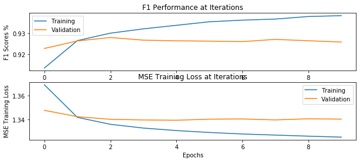

```python
plt.figure(figsize=(10,4))
plt.subplot(2,1,1)
plt.ylabel('F1 Scores %')
plt.xlabel('Epochs')
plt.title('F1 Performance at Iterations')
plt.plot(history.history['F1'], label='Training')
plt.plot(history.history['val_F1'], label='Validation')
plt.legend()

plt.subplot(2,1,2)
plt.ylabel('MSE Training Loss')
plt.xlabel('Epochs')
plt.title('MSE Training Loss at Iterations')
plt.plot(history.history['loss'], label='Training')
plt.plot(history.history['val_loss'], label='Validation')
plt.legend()
```

The graph comes from modeling, the curve is rational and not overlapping. So it is not overfit, our train and test data performs well.

## 2. Modeling

### 2.1 Create at least three combined wide and deep networks to classify your data using Keras. Visualize the performance of the network on the training data and validation data in the same plot versus the training iterations. Note: use the "history" return parameter that is part of Keras "fit" function to easily access this data.

```python
from sklearn import metrics as mt
import keras

keras.__version__
```

```
'2.3.1'
```

```python
# from keras.models import Sequential
from keras.layers import Dense, Activation, Input
from keras.layers import Embedding, Flatten, concatenate
from keras.models import Model
```

```python
cross_column1 = [['State','County'],
                 ['Transit','Unemployment']]
cross_column2 = [['State','County'],
                 ['Transit','Unemployment'],
                 ['State','Unemployment']]
cross_column3 = [['State','County'],
                 ['Transit','Unemployment'],
                 ['State','Unemployment'],
                 ['County', 'Transit', 'Unemployment']]
```

we make these three types of crossed columns for three wide and deep network models. 1>first type: we cross state and county together, and then cross Transit and unemployment together. 2>second type: we cross state and county together, and then cross Transit and unemployment together, and then adding state and unemplyment together. 3>third type: we cross state and county together, and then cross Transit and unemployment together, and then crossing state and unemplyment together, and then crossing county and transit and unemployment together.

##### First wide and deep networks--use cross_column1

```python
#Citation From our Notebooks:https://github.com/eclarson/MachineLearningNotebooks/blob/master/10.%20Keras%20Wide%20and%20Deep.ipynb
cross_columns = cross_column1

# we need to create separate lists for each branch
embed_branches = []
X_ints_train = []
X_ints_test = []
all_inputs = []
all_wide_branch_outputs = []

for cols in cross_columns:
    # encode crossed columns as ints for the embedding
    enc = LabelEncoder()

    # create crossed labels
    X_crossed_train = X_df_train[cols].apply(lambda x: '_'.join(x), axis=1)
    X_crossed_test = X_df_test[cols].apply(lambda x: '_'.join(x), axis=1)

    enc.fit(np.hstack((X_crossed_train.values,  X_crossed_test.values)))
    X_crossed_train = enc.transform(X_crossed_train)
    X_crossed_test = enc.transform(X_crossed_test)
    X_ints_train.append(X_crossed_train)
    X_ints_test.append(X_crossed_test)

    # get the number of categories
    N = max(X_ints_train[-1]+1) # same as the max(df_train[col])

    # create embedding branch from the number of categories
    inputs = Input(shape=(1,),dtype='int32', name = '_'.join(cols))
    all_inputs.append(inputs)
    x = Embedding(input_dim=N,
                  output_dim=int(np.sqrt(N)),
                  input_length=1, name = '_'.join(cols)+'_embed')(inputs)
    x = Flatten()(x)
    all_wide_branch_outputs.append(x)

# merge the branches together
wide_branch = concatenate(all_wide_branch_outputs, name='wide_concat')
wide_branch = Dense(units=1,activation='sigmoid',name='wide_combined')(wide_branch)

# reset this input branch
all_deep_branch_outputs = []
# add in the embeddings
for col in categorical_headers_ints:
    # encode as ints for the embedding
    X_ints_train.append(X_df_train[col].values)
    X_ints_test.append(X_df_test[col].values)

    # get the number of categories
    N = max(X_ints_train[-1]+1) # same as the max(df_train[col])

    # create embedding branch from the number of categories
    inputs = Input(shape=(1,),dtype='int32', name=col)
    all_inputs.append(inputs)
    x = Embedding(input_dim=N,
                  output_dim=int(np.sqrt(N)),
                  input_length=1, name=col+'_embed')(inputs)
    x = Flatten()(x)
    all_deep_branch_outputs.append(x)

# also get a dense branch of the numeric features
all_inputs.append(Input(shape=(X_train_num.shape[1],),
                        sparse=False,
                        name='numeric_data'))

x = Dense(units=20, activation='relu',name='numeric_1')(all_inputs[-1])
all_deep_branch_outputs.append( x )

# merge the deep branches together
deep_branch = concatenate(all_deep_branch_outputs,name='concat_embeds')
deep_branch = Dense(units=50,activation='relu', name='deep1')(deep_branch)
deep_branch = Dense(units=25,activation='relu', name='deep2')(deep_branch)
deep_branch = Dense(units=10,activation='relu', name='deep3')(deep_branch)

final_branch = concatenate([wide_branch, deep_branch],name='concat_deep_wide')
final_branch = Dense(units=1,activation='sigmoid',name='combined')(final_branch)

model = Model(inputs=all_inputs, outputs=final_branch)
```

```python
model.summary()
```

```
Model: "model_1"
__________________________________________________________________________________________________
Layer (type)                    Output Shape         Param #     Connected to
==================================================================================================
State_int (InputLayer)          (None, 1)            0
__________________________________________________________________________________________________
County_int (InputLayer)         (None, 1)            0
__________________________________________________________________________________________________
Transit_int (InputLayer)        (None, 1)            0
__________________________________________________________________________________________________
Unemployment_int (InputLayer)   (None, 1)            0
__________________________________________________________________________________________________
State_int_embed (Embedding)     (None, 1, 7)         364         State_int[0][0]
__________________________________________________________________________________________________
County_int_embed (Embedding)    (None, 1, 44)        85976       County_int[0][0]
__________________________________________________________________________________________________
Transit_int_embed (Embedding)   (None, 1, 2)         8           Transit_int[0][0]
__________________________________________________________________________________________________
Unemployment_int_embed (Embeddi (None, 1, 2)         10          Unemployment_int[0][0]
__________________________________________________________________________________________________
numeric_data (InputLayer)       (None, 14)           0
__________________________________________________________________________________________________
State_County (InputLayer)       (None, 1)            0
__________________________________________________________________________________________________
Transit_Unemployment (InputLaye (None, 1)            0
__________________________________________________________________________________________________
flatten_3 (Flatten)             (None, 7)            0           State_int_embed[0][0]
__________________________________________________________________________________________________
flatten_4 (Flatten)             (None, 44)           0           County_int_embed[0][0]
__________________________________________________________________________________________________
flatten_5 (Flatten)             (None, 2)            0           Transit_int_embed[0][0]
__________________________________________________________________________________________________
flatten_6 (Flatten)             (None, 2)            0           Unemployment_int_embed[0][0]
__________________________________________________________________________________________________
numeric_1 (Dense)               (None, 20)           300         numeric_data[0][0]
__________________________________________________________________________________________________
State_County_embed (Embedding)  (None, 1, 56)        180264      State_County[0][0]
__________________________________________________________________________________________________
Transit_Unemployment_embed (Emb (None, 1, 4)         80          Transit_Unemployment[0][0]
__________________________________________________________________________________________________
```

[output cut: 15 more lines]

```
deep2 (Dense)                   (None, 25)           1275        deep1[0][0]
__________________________________________________________________________________________________
wide_combined (Dense)           (None, 1)            61          wide_concat[0][0]
__________________________________________________________________________________________________
deep3 (Dense)                   (None, 10)           260         deep2[0][0]
__________________________________________________________________________________________________
concat_deep_wide (Concatenate)  (None, 11)           0           wide_combined[0][0]
                                                                 deep3[0][0]
__________________________________________________________________________________________________
combined (Dense)                (None, 1)            12          concat_deep_wide[0][0]
==================================================================================================
Total params: 272,410
Trainable params: 272,410
Non-trainable params: 0
__________________________________________________________________________________________________
```

```python
from IPython.display import SVG
from keras.utils.vis_utils import model_to_dot
SVG(model_to_dot(model, show_shapes= True, show_layer_names=True, dpi=65).create(prog='dot', format='svg'))

# you will need to install pydot properly on your machine to get this running
# SVG(model_to_dot(model).create(prog='dot', format='svg'))
```

[figure not shown]

From the construction above, we can clearly see the relationship between our layers. Also, input range and output range can also be shown in the constuction. Then we begin to define F1 function, which will be used evaluate your algorithm’s performance.

Precision - Precision is the ratio of correctly predicted positive observations to the total predicted positive observations.  
Precision = TP/TP+FP

Recall (Sensitivity) - Recall is the ratio of correctly predicted positive observations to the all observations in actual class - yes.  
Recall = TP/TP+FN

F1 score - F1 Score is the weighted average of Precision and Recall. Therefore, this score takes both false positives and false negatives into account. Intuitively it is not as easy to understand as accuracy, but F1 is usually more useful than accuracy, especially if you have an uneven class distribution. Accuracy works best if false positives and false negatives have similar cost. If the cost of false positives and false negatives are very different, it’s better to look at both Precision and Recall.  
F1 Score = 2*(Recall* Precision) / (Recall + Precision)

Considering F1 score is more comprehesive, we choose F1 score.  
Conception cited from:https://blog.exsilio.com/all/accuracy-precision-recall-f1-score-interpretation-of-performance-measures/

```python
from keras import backend as K
def Precision(y_true, y_pred):
    """Precision"""
    tp= K.sum(K.round(K.clip(y_true * y_pred, 0, 1)))  # true positives
    pp= K.sum(K.round(K.clip(y_pred, 0, 1))) # predicted positives
    precision = tp/ (pp+ K.epsilon())
    return precision

def Recall(y_true, y_pred):
    """Recall"""
    tp = K.sum(K.round(K.clip(y_true * y_pred, 0, 1))) # true positives
    pp = K.sum(K.round(K.clip(y_true, 0, 1))) # possible positives
    recall = tp / (pp + K.epsilon())
    return recall
def F1(y_true, y_pred):
    """F1-score"""
    precision = Precision(y_true, y_pred)
    recall = Recall(y_true, y_pred)
    f1 = 2 * ((precision * recall) / (precision + recall + K.epsilon()))
    return f1
```

```python
model.compile(optimizer='adagrad',
              loss='mean_squared_error',
              metrics=[F1,'accuracy'])

# lets also add the history variable to see how we are doing
# and lets add a validation set to keep track of our progress
history = model.fit(X_ints_train+ [X_train_num],
                    y_train,
                    epochs=10,
                    batch_size=50,
                    verbose=1,
                    validation_data = (X_ints_test + [X_test_num], y_test))
```

```
Train on 58174 samples, validate on 14544 samples
```

```python
yhat = np.round(model.predict(X_ints_test + [X_test_num]))
print(mt.confusion_matrix(y_test,yhat), mt.f1_score(y_test,yhat, average='weighted'))
```

```
[[2755  940    0    0]
 [ 680 2905    0    0]
 [  16 3614    0    0]
 [   5 3629    0    0]] 0.2933589943670499
```

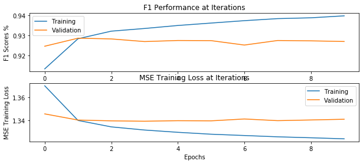

```python
%matplotlib inline

plt.figure(figsize=(10,4))
plt.subplot(2,1,1)
plt.ylabel('F1 Scores %')
plt.xlabel('Epochs')
plt.title('F1 Performance at Iterations')
plt.plot(history.history['F1'], label='Training')
plt.plot(history.history['val_F1'], label='Validation')
plt.legend()

plt.subplot(2,1,2)
plt.ylabel('MSE Training Loss')
plt.xlabel('Epochs')
plt.title('MSE Training Loss at Iterations')
plt.plot(history.history['loss'], label='Training')
plt.plot(history.history['val_loss'], label='Validation')
plt.legend()
```

From the graph, the training curve is close to validation curve. Because of our large data size, the plot doesn't show overfit. It also explain why we do not need to do cross validation.

##### Second wide and deep networks-- use cross_column2

```python
cross_columns = cross_column2

# we need to create separate lists for each branch
embed_branches = []
X_ints_train = []
X_ints_test = []
all_inputs = []
all_wide_branch_outputs = []

for cols in cross_columns:
    # encode crossed columns as ints for the embedding
    enc = LabelEncoder()

    # create crossed labels
    X_crossed_train = X_df_train[cols].apply(lambda x: '_'.join(x), axis=1)
    X_crossed_test = X_df_test[cols].apply(lambda x: '_'.join(x), axis=1)

    enc.fit(np.hstack((X_crossed_train.values,  X_crossed_test.values)))
    X_crossed_train = enc.transform(X_crossed_train)
    X_crossed_test = enc.transform(X_crossed_test)
    X_ints_train.append(X_crossed_train)
    X_ints_test.append(X_crossed_test)

    # get the number of categories
    N = max(X_ints_train[-1]+1) # same as the max(df_train[col])

    # create embedding branch from the number of categories
    inputs = Input(shape=(1,),dtype='int32', name = '_'.join(cols))
    all_inputs.append(inputs)
    x = Embedding(input_dim=N,
                  output_dim=int(np.sqrt(N)),
                  input_length=1, name = '_'.join(cols)+'_embed')(inputs)
    x = Flatten()(x)
    all_wide_branch_outputs.append(x)

# merge the branches together
wide_branch = concatenate(all_wide_branch_outputs, name='wide_concat')
wide_branch = Dense(units=1,activation='sigmoid',name='wide_combined')(wide_branch)

# reset this input branch
all_deep_branch_outputs = []
# add in the embeddings
for col in categorical_headers_ints:
    # encode as ints for the embedding
    X_ints_train.append(X_df_train[col].values)
    X_ints_test.append(X_df_test[col].values)

    # get the number of categories
    N = max(X_ints_train[-1]+1) # same as the max(df_train[col])

    # create embedding branch from the number of categories
    inputs = Input(shape=(1,),dtype='int32', name=col)
    all_inputs.append(inputs)
    x = Embedding(input_dim=N,
                  output_dim=int(np.sqrt(N)),
                  input_length=1, name=col+'_embed')(inputs)
    x = Flatten()(x)
    all_deep_branch_outputs.append(x)

# also get a dense branch of the numeric features
all_inputs.append(Input(shape=(X_train_num.shape[1],),
                        sparse=False,
                        name='numeric_data'))

x = Dense(units=20, activation='relu',name='numeric_1')(all_inputs[-1])
all_deep_branch_outputs.append( x )

# merge the deep branches together
deep_branch = concatenate(all_deep_branch_outputs,name='concat_embeds')
deep_branch = Dense(units=50,activation='relu', name='deep1')(deep_branch)
deep_branch = Dense(units=25,activation='relu', name='deep2')(deep_branch)
deep_branch = Dense(units=10,activation='relu', name='deep3')(deep_branch)

final_branch = concatenate([wide_branch, deep_branch],name='concat_deep_wide')
final_branch = Dense(units=1,activation='sigmoid',name='combined')(final_branch)

model = Model(inputs=all_inputs, outputs=final_branch)
```

```python
model.summary()
```

```
Model: "model_3"
__________________________________________________________________________________________________
Layer (type)                    Output Shape         Param #     Connected to
==================================================================================================
State_int (InputLayer)          (None, 1)            0
__________________________________________________________________________________________________
County_int (InputLayer)         (None, 1)            0
__________________________________________________________________________________________________
Transit_int (InputLayer)        (None, 1)            0
__________________________________________________________________________________________________
Unemployment_int (InputLayer)   (None, 1)            0
__________________________________________________________________________________________________
State_int_embed (Embedding)     (None, 1, 7)         364         State_int[0][0]
__________________________________________________________________________________________________
County_int_embed (Embedding)    (None, 1, 44)        85976       County_int[0][0]
__________________________________________________________________________________________________
Transit_int_embed (Embedding)   (None, 1, 2)         8           Transit_int[0][0]
__________________________________________________________________________________________________
Unemployment_int_embed (Embeddi (None, 1, 2)         10          Unemployment_int[0][0]
__________________________________________________________________________________________________
numeric_data (InputLayer)       (None, 14)           0
__________________________________________________________________________________________________
State_County (InputLayer)       (None, 1)            0
__________________________________________________________________________________________________
Transit_Unemployment (InputLaye (None, 1)            0
__________________________________________________________________________________________________
State_Unemployment (InputLayer) (None, 1)            0
__________________________________________________________________________________________________
flatten_16 (Flatten)            (None, 7)            0           State_int_embed[0][0]
__________________________________________________________________________________________________
flatten_17 (Flatten)            (None, 44)           0           County_int_embed[0][0]
__________________________________________________________________________________________________
flatten_18 (Flatten)            (None, 2)            0           Transit_int_embed[0][0]
__________________________________________________________________________________________________
flatten_19 (Flatten)            (None, 2)            0           Unemployment_int_embed[0][0]
__________________________________________________________________________________________________
numeric_1 (Dense)               (None, 20)           300         numeric_data[0][0]
__________________________________________________________________________________________________
State_County_embed (Embedding)  (None, 1, 56)        180264      State_County[0][0]
__________________________________________________________________________________________________
```

[output cut: 22 more lines]

```
deep2 (Dense)                   (None, 25)           1275        deep1[0][0]
__________________________________________________________________________________________________
wide_combined (Dense)           (None, 1)            76          wide_concat[0][0]
__________________________________________________________________________________________________
deep3 (Dense)                   (None, 10)           260         deep2[0][0]
__________________________________________________________________________________________________
concat_deep_wide (Concatenate)  (None, 11)           0           wide_combined[0][0]
                                                                 deep3[0][0]
__________________________________________________________________________________________________
combined (Dense)                (None, 1)            12          concat_deep_wide[0][0]
==================================================================================================
Total params: 276,220
Trainable params: 276,220
Non-trainable params: 0
__________________________________________________________________________________________________
```

```python
# you will need to install pydot properly on your machine to get this running
# SVG(model_to_dot(model).create(prog='dot', format='svg'))
SVG(model_to_dot(model, show_shapes= True, show_layer_names=True, dpi=65).create(prog='dot', format='svg'))
```

[figure not shown]

```python
model.compile(optimizer='adagrad',
              loss='mean_squared_error',
              metrics=[F1,'accuracy'])

# lets also add the history variable to see how we are doing
# and lets add a validation set to keep track of our progress
history = model.fit(X_ints_train+ [X_train_num],
                    y_train,
                    epochs=10,
                    batch_size=30,
                    verbose=1,
                    validation_data = (X_ints_test + [X_test_num], y_test))
```

```
Train on 58174 samples, validate on 14544 samples
```

```python
yhat = np.round(model.predict(X_ints_test + [X_test_num]))
print(mt.confusion_matrix(y_test,yhat), mt.f1_score(y_test,yhat, average='weighted'))
```

```
[[2692 1003    0    0]
 [ 620 2965    0    0]
 [  17 3613    0    0]
 [   4 3630    0    0]] 0.293417962099206
```

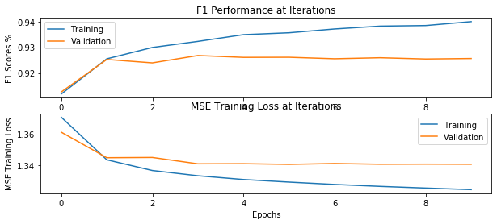

```python
%matplotlib inline

plt.figure(figsize=(10,4))
plt.subplot(2,1,1)
plt.ylabel('F1 Scores %')
plt.xlabel('Epochs')
plt.title('F1 Performance at Iterations')
plt.plot(history.history['F1'], label='Training')
plt.plot(history.history['val_F1'], label='Validation')
plt.legend()

plt.subplot(2,1,2)
plt.ylabel('MSE Training Loss')
plt.xlabel('Epochs')
plt.title('MSE Training Loss at Iterations')
plt.plot(history.history['loss'], label='Training')
plt.plot(history.history['val_loss'], label='Validation')
plt.legend()
```

##### Third wide and deep network--use cross_column3

```python
cross_columns = cross_column3

# we need to create separate lists for each branch
embed_branches = []
X_ints_train = []
X_ints_test = []
all_inputs = []
all_wide_branch_outputs = []

for cols in cross_columns:
    # encode crossed columns as ints for the embedding
    enc = LabelEncoder()

    # create crossed labels
    X_crossed_train = X_df_train[cols].apply(lambda x: '_'.join(x), axis=1)
    X_crossed_test = X_df_test[cols].apply(lambda x: '_'.join(x), axis=1)

    enc.fit(np.hstack((X_crossed_train.values,  X_crossed_test.values)))
    X_crossed_train = enc.transform(X_crossed_train)
    X_crossed_test = enc.transform(X_crossed_test)
    X_ints_train.append(X_crossed_train)
    X_ints_test.append(X_crossed_test)

    # get the number of categories
    N = max(X_ints_train[-1]+1) # same as the max(df_train[col])

    # create embedding branch from the number of categories
    inputs = Input(shape=(1,),dtype='int32', name = '_'.join(cols))
    all_inputs.append(inputs)
    x = Embedding(input_dim=N,
                  output_dim=int(np.sqrt(N)),
                  input_length=1, name = '_'.join(cols)+'_embed')(inputs)
    x = Flatten()(x)
    all_wide_branch_outputs.append(x)

# merge the branches together
wide_branch = concatenate(all_wide_branch_outputs, name='wide_concat')
wide_branch = Dense(units=1,activation='sigmoid',name='wide_combined')(wide_branch)

# reset this input branch
all_deep_branch_outputs = []
# add in the embeddings
for col in categorical_headers_ints:
    # encode as ints for the embedding
    X_ints_train.append(X_df_train[col].values)
    X_ints_test.append(X_df_test[col].values)

    # get the number of categories
    N = max(X_ints_train[-1]+1) # same as the max(df_train[col])

    # create embedding branch from the number of categories
    inputs = Input(shape=(1,),dtype='int32', name=col)
    all_inputs.append(inputs)
    x = Embedding(input_dim=N,
                  output_dim=int(np.sqrt(N)),
                  input_length=1, name=col+'_embed')(inputs)
    x = Flatten()(x)
    all_deep_branch_outputs.append(x)

# also get a dense branch of the numeric features
all_inputs.append(Input(shape=(X_train_num.shape[1],),
                        sparse=False,
                        name='numeric_data'))

x = Dense(units=20, activation='relu',name='numeric_1')(all_inputs[-1])
all_deep_branch_outputs.append( x )

# merge the deep branches together
deep_branch = concatenate(all_deep_branch_outputs,name='concat_embeds')
deep_branch = Dense(units=50,activation='relu', name='deep1')(deep_branch)
deep_branch = Dense(units=25,activation='relu', name='deep2')(deep_branch)
deep_branch = Dense(units=10,activation='relu', name='deep3')(deep_branch)

final_branch = concatenate([wide_branch, deep_branch],name='concat_deep_wide')
final_branch = Dense(units=1,activation='sigmoid',name='combined')(final_branch)

model = Model(inputs=all_inputs, outputs=final_branch)
```

```python
model.summary()
```

```
Model: "model_4"
__________________________________________________________________________________________________
Layer (type)                    Output Shape         Param #     Connected to
==================================================================================================
State_int (InputLayer)          (None, 1)            0
__________________________________________________________________________________________________
County_int (InputLayer)         (None, 1)            0
__________________________________________________________________________________________________
Transit_int (InputLayer)        (None, 1)            0
__________________________________________________________________________________________________
Unemployment_int (InputLayer)   (None, 1)            0
__________________________________________________________________________________________________
State_int_embed (Embedding)     (None, 1, 7)         364         State_int[0][0]
__________________________________________________________________________________________________
County_int_embed (Embedding)    (None, 1, 44)        85976       County_int[0][0]
__________________________________________________________________________________________________
Transit_int_embed (Embedding)   (None, 1, 2)         8           Transit_int[0][0]
__________________________________________________________________________________________________
Unemployment_int_embed (Embeddi (None, 1, 2)         10          Unemployment_int[0][0]
__________________________________________________________________________________________________
numeric_data (InputLayer)       (None, 14)           0
__________________________________________________________________________________________________
State_County (InputLayer)       (None, 1)            0
__________________________________________________________________________________________________
Transit_Unemployment (InputLaye (None, 1)            0
__________________________________________________________________________________________________
State_Unemployment (InputLayer) (None, 1)            0
__________________________________________________________________________________________________
County_Transit_Unemployment (In (None, 1)            0
__________________________________________________________________________________________________
flatten_24 (Flatten)            (None, 7)            0           State_int_embed[0][0]
__________________________________________________________________________________________________
flatten_25 (Flatten)            (None, 44)           0           County_int_embed[0][0]
__________________________________________________________________________________________________
flatten_26 (Flatten)            (None, 2)            0           Transit_int_embed[0][0]
__________________________________________________________________________________________________
flatten_27 (Flatten)            (None, 2)            0           Unemployment_int_embed[0][0]
__________________________________________________________________________________________________
numeric_1 (Dense)               (None, 20)           300         numeric_data[0][0]
__________________________________________________________________________________________________
```

[output cut: 29 more lines]

```
deep2 (Dense)                   (None, 25)           1275        deep1[0][0]
__________________________________________________________________________________________________
wide_combined (Dense)           (None, 1)            187         wide_concat[0][0]
__________________________________________________________________________________________________
deep3 (Dense)                   (None, 10)           260         deep2[0][0]
__________________________________________________________________________________________________
concat_deep_wide (Concatenate)  (None, 11)           0           wide_combined[0][0]
                                                                 deep3[0][0]
__________________________________________________________________________________________________
combined (Dense)                (None, 1)            12          concat_deep_wide[0][0]
==================================================================================================
Total params: 1,651,288
Trainable params: 1,651,288
Non-trainable params: 0
__________________________________________________________________________________________________
```

```python
# you will need to install pydot properly on your machine to get this running
# SVG(model_to_dot(model).create(prog='dot', format='svg'))
SVG(model_to_dot(model, show_shapes= True, show_layer_names=True, dpi=65).create(prog='dot', format='svg'))
```

[figure not shown]

```python
model.compile(optimizer='adagrad',
              loss='mean_squared_error',
              metrics=[F1,'accuracy'])

# lets also add the history variable to see how we are doing
# and lets add a validation set to keep track of our progress
history = model.fit(X_ints_train+ [X_train_num],
                    y_train,
                    epochs=10,
                    batch_size=30,
                    verbose=1,
                    validation_data = (X_ints_test + [X_test_num], y_test))
```

```
Train on 58174 samples, validate on 14544 samples
```

```python
yhat = np.round(model.predict(X_ints_test + [X_test_num]))
print(mt.confusion_matrix(y_test,yhat), mt.f1_score(y_test,yhat, average='weighted'))
```

```
[[2707  988    0    0]
 [ 631 2954    0    0]
 [  13 3617    0    0]
 [   3 3631    0    0]] 0.293692768284716
```

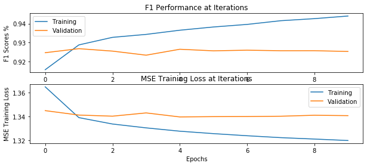

```python
%matplotlib inline

plt.figure(figsize=(10,4))
plt.subplot(2,1,1)
plt.ylabel('F1 Scores %')
plt.xlabel('Epochs')
plt.title('F1 Performance at Iterations')
plt.plot(history.history['F1'], label='Training')
plt.plot(history.history['val_F1'], label='Validation')
plt.legend()

plt.subplot(2,1,2)
plt.ylabel('MSE Training Loss')
plt.xlabel('Epochs')
plt.title('MSE Training Loss at Iterations')
plt.plot(history.history['loss'], label='Training')
plt.plot(history.history['val_loss'], label='Validation')
plt.legend()
```

### 2.2 Investigate generalization performance by altering the number of layers in the deep branch of the network. Try at least two different number of layers. Use the method of cross validation and evaluation metric that you argued for at the beginning of the lab to select the number of layers that performs superiorly.

After searching on google, we find some rule about choose number of hidden layer(cite from:https://www.heatonresearch.com/2017/06/01/hidden-layers.html):

The number of hidden neurons should be between the size of the input layer and the size of the output layer.  
The number of hidden neurons should be 2/3 the size of the input layer, plus the size of the output layer.  
The number of hidden neurons should be less than twice the size of the input layer  
Considering about running time, we choose 5 10 20 40 80...

```python
def AlterLayer_network(layers=[]):
    cross_columns = cross_column1

    # we need to create separate lists for each branch
    embed_branches = []
    X_ints_train = []
    X_ints_test = []
    all_inputs = []
    all_wide_branch_outputs = []

    for cols in cross_columns:
        # encode crossed columns as ints for the embedding
        enc = LabelEncoder()

        # create crossed labels
        X_crossed_train = X_df_train[cols].apply(lambda x: '_'.join(x), axis=1)
        X_crossed_test = X_df_test[cols].apply(lambda x: '_'.join(x), axis=1)

        enc.fit(np.hstack((X_crossed_train.values,  X_crossed_test.values)))
        X_crossed_train = enc.transform(X_crossed_train)
        X_crossed_test = enc.transform(X_crossed_test)
        X_ints_train.append(X_crossed_train)
        X_ints_test.append(X_crossed_test)

        # get the number of categories
        N = max(X_ints_train[-1]+1) # same as the max(df_train[col])

        # create embedding branch from the number of categories
        inputs = Input(shape=(1,),dtype='int32', name = '_'.join(cols))
        all_inputs.append(inputs)
        x = Embedding(input_dim=N,
                      output_dim=int(np.sqrt(N)),
                      input_length=1, name = '_'.join(cols)+'_embed')(inputs)
        x = Flatten()(x)
        all_wide_branch_outputs.append(x)

    # merge the branches together
    wide_branch = concatenate(all_wide_branch_outputs, name='wide_concat')
    wide_branch = Dense(units=1,activation='sigmoid',name='wide_combined')(wide_branch)

    # reset this input branch
    all_deep_branch_outputs = []
    # add in the embeddings
    for col in categorical_headers_ints:
        # encode as ints for the embedding
        X_ints_train.append(X_df_train[col].values)
        X_ints_test.append(X_df_test[col].values)

        # get the number of categories
        N = max(X_ints_train[-1]+1) # same as the max(df_train[col])

        # create embedding branch from the number of categories
        inputs = Input(shape=(1,),dtype='int32', name=col)
        all_inputs.append(inputs)
        x = Embedding(input_dim=N,
                      output_dim=int(np.sqrt(N)),
                      input_length=1, name=col+'_embed')(inputs)
        x = Flatten()(x)
        all_deep_branch_outputs.append(x)

    # also get a dense branch of the numeric features
    all_inputs.append(Input(shape=(X_train_num.shape[1],),
                            sparse=False,
                            name='numeric_data'))

    x = Dense(units=20, activation='relu',name='numeric_1')(all_inputs[-1])
    all_deep_branch_outputs.append( x )

    # merge the deep branches together
    deep_branch = concatenate(all_deep_branch_outputs,name='concat_embeds')
    for idx, layer in enumerate(layers):
        deep_branch = Dense(units=layer,activation='relu', name='deep{}'.format(str(idx+1)))(deep_branch)

    final_branch = concatenate([wide_branch, deep_branch],name='concat_deep_wide')
    final_branch = Dense(units=1,activation='sigmoid',name='combined')(final_branch)

    model = Model(inputs=all_inputs, outputs=final_branch)
    model.compile(optimizer='adagrad',
                  loss='mean_squared_error',
                  metrics=[F1,'accuracy'])

    X_train = X_ints_train+ [X_train_num]
    X_test = X_ints_test + [X_test_num]

    return model, X_train, X_test
```

```python
model1, X_train1, X_test1 = AlterLayer_network(layers=[20,10,5])
model2, X_train2, X_test2 = AlterLayer_network(layers=[40,20,10,5])
model3, X_train3, X_test3 = AlterLayer_network(layers=[80,40,20,10,5])
```

```python
history1 = model1.fit(X_train1, y_train, epochs=20, batch_size=50, verbose=1)
```

```python
history2 = model1.fit(X_train2, y_train, epochs=20, batch_size=50, verbose=1)
```

```python
history3 = model1.fit(X_train3, y_train, epochs=20, batch_size=50, verbose=1)
```

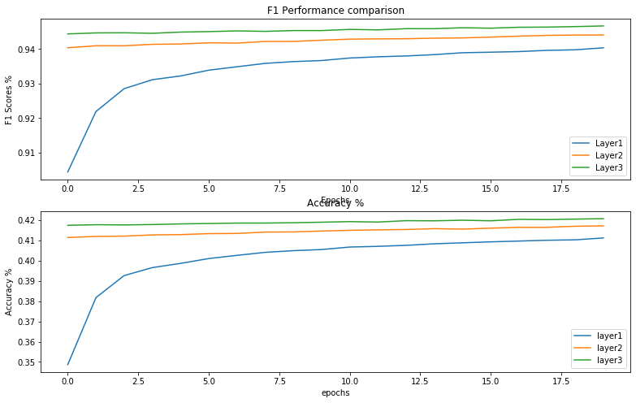

```python
%matplotlib inline

plt.figure(figsize=(13,8))
plt.subplot(2,1,1)
plt.ylabel('F1 Scores %')
plt.xlabel('Epochs')
plt.title('F1 Performance comparison')
plt.plot(history1.history['F1'], label='Layer1')
plt.plot(history2.history['F1'], label='Layer2')
plt.plot(history3.history['F1'], label='Layer3')
plt.legend()

plt.subplot(2,1,2)
plt.ylabel('Accuracy %')
plt.xlabel('epochs')
plt.title('Accuracy %')
plt.plot(history1.history['accuracy'], label='layer1')
plt.plot(history2.history['accuracy'], label='layer2')
plt.plot(history3.history['accuracy'], label='layer3')
plt.legend()
```

### 2.3 Compare the performance of your best wide and deep network to a standard multi-layer perceptron (MLP). For classification tasks, use the receiver operating characteristic and area under the curve. For regression tasks, use Bland-Altman plots and residual variance calculations. Use proper statistical method to compare the performance of different models.

#### ROC

```python
import numpy as np
import matplotlib.pyplot as plt
from itertools import cycle

from sklearn import svm, datasets
from sklearn.metrics import roc_curve, auc
from sklearn.model_selection import train_test_split
from sklearn.preprocessing import label_binarize
from sklearn.multiclass import OneVsRestClassifier
from scipy import interp
from sklearn.metrics import roc_auc_score
```

```python
df['ChildPoverty'] = label_binarize(df['ChildPoverty'], classes=[0, 1, 2])
```

Because our model is for multiclass, we should convert it to binary. ROC is used for binary. we use label_binarize function here to convert our target to binary. Then we redo our train and test work.

```python
from sklearn.model_selection import train_test_split

X_df_train, X_df_test = train_test_split(df, test_size=0.2, random_state=10, stratify=df['ChildPoverty'])
y_train = X_df_train['ChildPoverty'].values.astype(np.int)
y_test = X_df_test['ChildPoverty'].values.astype(np.int)

X_train_num =  X_df_train[numeric_headers].values
X_test_num = X_df_test[numeric_headers].values
```

```python
X_train1 = X_df_train[feature_columns].values
X_test1 = X_df_test[feature_columns].values
y_train1 = X_df_train['ChildPoverty'].values.astype(np.int)
y_test1 = X_df_test['ChildPoverty'].values.astype(np.int)
```

```python
from keras.models import Sequential
from keras.layers.core import Dense, Dropout, Activation
from keras.optimizers import SGD
from sklearn.metrics import roc_curve, auc

# This returns a tensor
inputs = Input(shape=(X_train1.shape[1],))

# a layer instance is callable on a tensor, and returns a tensor
x = Dense(units=80, activation='relu')(inputs)
x = Dense(units=40, activation='tanh')(x)
x = Dense(units=20, activation='tanh')(x)
x = Dense(units=10, activation='tanh')(x)
x = Dense(units=5, activation='tanh')(x)
predictions = Dense(1,activation='sigmoid')(x)

# This creates a model that includes
# the Input layer and three Dense layers
model1 = Model(inputs=inputs, outputs=predictions)

sgd = SGD(lr=0.1, decay=1e-6, momentum=0.9, nesterov=True)
model1.compile(loss='mean_squared_error', optimizer=sgd, metrics=[Recall])
```

model1 is from tensflow.

```python
def wide_deep_network1(layers=[]):
    cross_columns = cross_column1

    # we need to create separate lists for each branch
    embed_branches = []
    X_ints_train = []
    X_ints_test = []
    all_inputs = []
    all_wide_branch_outputs = []

    for cols in cross_columns:
        # encode crossed columns as ints for the embedding
        enc = LabelEncoder()

        # create crossed labels
        X_crossed_train = X_df_train[cols].apply(lambda x: '_'.join(x), axis=1)
        X_crossed_test = X_df_test[cols].apply(lambda x: '_'.join(x), axis=1)

        enc.fit(np.hstack((X_crossed_train.values,  X_crossed_test.values)))
        X_crossed_train = enc.transform(X_crossed_train)
        X_crossed_test = enc.transform(X_crossed_test)
        X_ints_train.append(X_crossed_train)
        X_ints_test.append(X_crossed_test)

        # get the number of categories
        N = max(X_ints_train[-1]+1) # same as the max(df_train[col])

        # create embedding branch from the number of categories
        inputs = Input(shape=(1,),dtype='int32', name = '_'.join(cols))
        all_inputs.append(inputs)
        x = Embedding(input_dim=N,
                      output_dim=int(np.sqrt(N)),
                      input_length=1, name = '_'.join(cols)+'_embed')(inputs)
        x = Flatten()(x)
        all_wide_branch_outputs.append(x)

    # merge the branches together
    wide_branch = concatenate(all_wide_branch_outputs, name='wide_concat')
    wide_branch = Dense(units=1,activation='sigmoid',name='wide_combined')(wide_branch)

    # reset this input branch
    all_deep_branch_outputs = []
    # add in the embeddings
    for col in categorical_headers_ints:
        # encode as ints for the embedding
        X_ints_train.append(X_df_train[col].values)
        X_ints_test.append(X_df_test[col].values)

        # get the number of categories
        N = max(X_ints_train[-1]+1) # same as the max(df_train[col])

        # create embedding branch from the number of categories
        inputs = Input(shape=(1,),dtype='int32', name=col)
        all_inputs.append(inputs)
        x = Embedding(input_dim=N,
                      output_dim=int(np.sqrt(N)),
                      input_length=1, name=col+'_embed')(inputs)
        x = Flatten()(x)
        all_deep_branch_outputs.append(x)

    # also get a dense branch of the numeric features
    all_inputs.append(Input(shape=(X_train_num.shape[1],),
                            sparse=False,
                            name='numeric_data'))

    x = Dense(units=20, activation='relu',name='numeric_1')(all_inputs[-1])
    all_deep_branch_outputs.append( x )

    # merge the deep branches together
    deep_branch = concatenate(all_deep_branch_outputs,name='concat_embeds')
    for idx, layer in enumerate(layers):
        deep_branch = Dense(units=layer,activation='relu', name='deep{}'.format(str(idx+1)))(deep_branch)

    final_branch = concatenate([wide_branch, deep_branch],name='concat_deep_wide')
    final_branch = Dense(units=1,activation='sigmoid',name='combined')(final_branch)

    model = Model(inputs=all_inputs, outputs=final_branch)
    model.compile(optimizer='adagrad',
                  loss='mean_squared_error',
                  metrics=[F1])

    X_train = X_ints_train+ [X_train_num]
    X_test = X_ints_test + [X_test_num]
    return model, X_train, X_test
```

```python
model2, X_train2, X_test2 = wide_deep_network1([80, 40, 20, 10, 5])
```

```python
def wide_deep_network2(layers=[]):
    cross_columns = cross_column2

    # we need to create separate lists for each branch
    embed_branches = []
    X_ints_train = []
    X_ints_test = []
    all_inputs = []
    all_wide_branch_outputs = []

    for cols in cross_columns:
        # encode crossed columns as ints for the embedding
        enc = LabelEncoder()

        # create crossed labels
        X_crossed_train = X_df_train[cols].apply(lambda x: '_'.join(x), axis=1)
        X_crossed_test = X_df_test[cols].apply(lambda x: '_'.join(x), axis=1)

        enc.fit(np.hstack((X_crossed_train.values,  X_crossed_test.values)))
        X_crossed_train = enc.transform(X_crossed_train)
        X_crossed_test = enc.transform(X_crossed_test)
        X_ints_train.append(X_crossed_train)
        X_ints_test.append(X_crossed_test)

        # get the number of categories
        N = max(X_ints_train[-1]+1) # same as the max(df_train[col])

        # create embedding branch from the number of categories
        inputs = Input(shape=(1,),dtype='int32', name = '_'.join(cols))
        all_inputs.append(inputs)
        x = Embedding(input_dim=N,
                      output_dim=int(np.sqrt(N)),
                      input_length=1, name = '_'.join(cols)+'_embed')(inputs)
        x = Flatten()(x)
        all_wide_branch_outputs.append(x)

    # merge the branches together
    wide_branch = concatenate(all_wide_branch_outputs, name='wide_concat')
    wide_branch = Dense(units=1,activation='sigmoid',name='wide_combined')(wide_branch)

    # reset this input branch
    all_deep_branch_outputs = []
    # add in the embeddings
    for col in categorical_headers_ints:
        # encode as ints for the embedding
        X_ints_train.append(X_df_train[col].values)
        X_ints_test.append(X_df_test[col].values)

        # get the number of categories
        N = max(X_ints_train[-1]+1) # same as the max(df_train[col])

        # create embedding branch from the number of categories
        inputs = Input(shape=(1,),dtype='int32', name=col)
        all_inputs.append(inputs)
        x = Embedding(input_dim=N,
                      output_dim=int(np.sqrt(N)),
                      input_length=1, name=col+'_embed')(inputs)
        x = Flatten()(x)
        all_deep_branch_outputs.append(x)

    # also get a dense branch of the numeric features
    all_inputs.append(Input(shape=(X_train_num.shape[1],),
                            sparse=False,
                            name='numeric_data'))

    x = Dense(units=20, activation='relu',name='numeric_1')(all_inputs[-1])
    all_deep_branch_outputs.append( x )

    # merge the deep branches together
    deep_branch = concatenate(all_deep_branch_outputs,name='concat_embeds')
    for idx, layer in enumerate(layers):
        deep_branch = Dense(units=layer,activation='relu', name='deep{}'.format(str(idx+1)))(deep_branch)

    final_branch = concatenate([wide_branch, deep_branch],name='concat_deep_wide')
    final_branch = Dense(units=1,activation='sigmoid',name='combined')(final_branch)

    model = Model(inputs=all_inputs, outputs=final_branch)
    model.compile(optimizer='adagrad',
                  loss='mean_squared_error',
                  metrics=[F1])

    X_train = X_ints_train+ [X_train_num]
    X_test = X_ints_test + [X_test_num]
    return model, X_train, X_test
```

```python
model3, X_train3, X_test3 = wide_deep_network2([80, 40, 20, 10, 5])
```

```python
model1.fit(X_train1, y_train1, epochs=10, batch_size=32, verbose=0)
yhat_proba1 = model1.predict(X_test1)
```

```python
model2.fit(X_train2, y_train1, epochs=10, batch_size=32, verbose=0)
yhat_proba2 = model2.predict(X_test2)
```

```python
model3.fit(X_train3, y_train1, epochs=10, batch_size=32, verbose=0)
yhat_proba3 = model3.predict(X_test3)
```

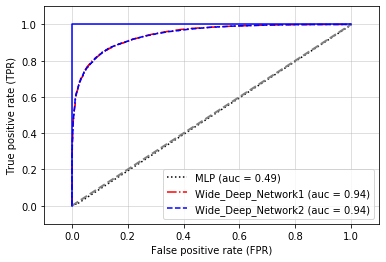

```python
from sklearn.metrics import roc_curve
from sklearn.metrics import auc
colors = ['black', 'red', 'blue']
linestyles = [':', '-.', '--']
labels = ['MLP', 'Wide_Deep_Network1', 'Wide_Deep_Network2']
score_compare = [(y_test1, yhat_proba1), (y_test, yhat_proba2), (y_test, yhat_proba3)]

for score_n, label, clr, ls in zip(score_compare, labels, colors, linestyles):
    fpr, tpr, thresholds = roc_curve(y_true=score_n[0], y_score=score_n[1])
    roc_auc = auc(x=fpr, y=tpr)
    plt.plot(fpr, tpr, color=clr, linestyle=ls, label='%s (auc = %0.2f)' % (label, roc_auc))


plt.legend(loc='lower right')
plt.plot([0, 1], [0, 1], linestyle='--', color='gray', linewidth=2)
plt.plot([0, 0, 1], [0, 1, 1], linestyle='-', color='blue', label='perfect performance')
plt.xlim([-0.1, 1.1])
plt.ylim([-0.1, 1.1])
plt.grid(alpha=0.5)
plt.xlabel('False positive rate (FPR)')
plt.ylabel('True positive rate (TPR)')
plt.figure(figsize=(20,10))
plt.show()
```

The ROC curve shows our wide_Deep_Newwork better than our model1(MLP), because the area under curve is much larger than MLP. Aslo, auc for bothWide_Deep_work1 and Wide_Deep_work2 is 0.94, which auc for MLP is 0.49. Wide_Deep_work1 performs well as well as Wide_Deep_work2, which means changing cross_columns do not influence our model much.

## Exceptional Work

##### One idea (required for 7000 level students): Capture the embedding weights from the deep network and (if needed) perform t-SNE dimensionality reduction on the output of these embedding layers (only if needed). That is, pass the observations into the network, save the embedded weights (called embeddings), and then perform dimensionality reduction in order to visualize results. Visualize and explain any clusters in the data.

```python
cross_columns = cross_column3

embed_branches = []
X_ints_train = []
X_ints_test = []
all_inputs = []
all_wide_branch_outputs = []

for cols in cross_columns:
    # encode crossed columns as ints for the embedding
    enc = LabelEncoder()

    # create crossed labels
    X_crossed_train = X_df_train[cols].apply(lambda x: '_'.join(x), axis=1)
    X_crossed_test = X_df_test[cols].apply(lambda x: '_'.join(x), axis=1)

    enc.fit(np.hstack((X_crossed_train.values,  X_crossed_test.values)))
    X_crossed_train = enc.transform(X_crossed_train)
    X_crossed_test = enc.transform(X_crossed_test)
    X_ints_train.append(X_crossed_train)
    X_ints_test.append(X_crossed_test)

    # get the number of categories
    N = max(X_ints_train[-1]+1) # same as the max(df_train[col])

    # create embedding branch from the number of categories
    inputs = Input(shape=(1,),dtype='int32', name = '_'.join(cols))
    all_inputs.append(inputs)
    x = Embedding(input_dim=N,
                  output_dim=int(np.sqrt(N)),
                  input_length=1, name = '_'.join(cols)+'_embed')(inputs)
    x = Flatten()(x)
    all_wide_branch_outputs.append(x)

# merge the branches together
wide_branch = concatenate(all_wide_branch_outputs, name='wide_concat')
wide_branch = Dense(units=1,activation='sigmoid',name='wide_combined')(wide_branch)

# reset this input branch
all_deep_branch_outputs = []
# add in the embeddings
for col in categorical_headers_ints:
    # encode as ints for the embedding
    X_ints_train.append(X_df_train[col].values)
    X_ints_test.append(X_df_test[col].values)

    # get the number of categories
    N = max(X_ints_train[-1]+1) # same as the max(df_train[col])

    # create embedding branch from the number of categories
    inputs = Input(shape=(1,),dtype='int32', name=col)
    all_inputs.append(inputs)
    x = Embedding(input_dim=N,
                  output_dim=int(np.sqrt(N)),
                  input_length=1, name=col+'_embed')(inputs)
    x = Flatten()(x)
    all_deep_branch_outputs.append(x)

# also get a dense branch of the numeric features
all_inputs.append(Input(shape=(X_train_num.shape[1],),
                        sparse=False,
                        name='numeric_data'))

x = Dense(units=20, activation='relu',name='numeric_1')(all_inputs[-1])
all_deep_branch_outputs.append( x )

# merge the deep branches together
deep_branch = concatenate(all_deep_branch_outputs,name='concat_embeds')
deep_branch = Dense(units=50,activation='relu', name='deep1')(deep_branch)
deep_branch = Dense(units=25,activation='relu', name='deep2')(deep_branch)
deep_branch = Dense(units=10,activation='relu', name='deep3')(deep_branch)

final_branch = concatenate([wide_branch, deep_branch],name='concat_deep_wide')
final_branch = Dense(units=1,activation='sigmoid',name='combined')(final_branch)

model = Model(inputs=all_inputs, outputs=final_branch)
```

```python
model.compile(optimizer='adagrad',
              loss='mean_squared_error',
              metrics=[F1])

# lets also add the history variable to see how we are doing
# and lets add a validation set to keep track of our progress
history = model.fit(X_ints_train+ [X_train_num],
                    y_train,
                    epochs=10,
                    batch_size=32,
                    verbose=0,
                    validation_data = (X_ints_test + [X_test_num], y_test))
```

```python
model.summary()
```

```
Model: "model_13"
__________________________________________________________________________________________________
Layer (type)                    Output Shape         Param #     Connected to
==================================================================================================
State_int (InputLayer)          (None, 1)            0
__________________________________________________________________________________________________
County_int (InputLayer)         (None, 1)            0
__________________________________________________________________________________________________
Transit_int (InputLayer)        (None, 1)            0
__________________________________________________________________________________________________
Unemployment_int (InputLayer)   (None, 1)            0
__________________________________________________________________________________________________
State_int_embed (Embedding)     (None, 1, 7)         364         State_int[0][0]
__________________________________________________________________________________________________
County_int_embed (Embedding)    (None, 1, 44)        85976       County_int[0][0]
__________________________________________________________________________________________________
Transit_int_embed (Embedding)   (None, 1, 2)         8           Transit_int[0][0]
__________________________________________________________________________________________________
Unemployment_int_embed (Embeddi (None, 1, 2)         10          Unemployment_int[0][0]
__________________________________________________________________________________________________
numeric_data (InputLayer)       (None, 14)           0
__________________________________________________________________________________________________
State_County (InputLayer)       (None, 1)            0
__________________________________________________________________________________________________
Transit_Unemployment (InputLaye (None, 1)            0
__________________________________________________________________________________________________
State_Unemployment (InputLayer) (None, 1)            0
__________________________________________________________________________________________________
County_Transit_Unemployment (In (None, 1)            0
__________________________________________________________________________________________________
flatten_70 (Flatten)            (None, 7)            0           State_int_embed[0][0]
__________________________________________________________________________________________________
flatten_71 (Flatten)            (None, 44)           0           County_int_embed[0][0]
__________________________________________________________________________________________________
flatten_72 (Flatten)            (None, 2)            0           Transit_int_embed[0][0]
__________________________________________________________________________________________________
flatten_73 (Flatten)            (None, 2)            0           Unemployment_int_embed[0][0]
__________________________________________________________________________________________________
numeric_1 (Dense)               (None, 20)           300         numeric_data[0][0]
__________________________________________________________________________________________________
```

[output cut: 29 more lines]

```
deep2 (Dense)                   (None, 25)           1275        deep1[0][0]
__________________________________________________________________________________________________
wide_combined (Dense)           (None, 1)            187         wide_concat[0][0]
__________________________________________________________________________________________________
deep3 (Dense)                   (None, 10)           260         deep2[0][0]
__________________________________________________________________________________________________
concat_deep_wide (Concatenate)  (None, 11)           0           wide_combined[0][0]
                                                                 deep3[0][0]
__________________________________________________________________________________________________
combined (Dense)                (None, 1)            12          concat_deep_wide[0][0]
==================================================================================================
Total params: 1,651,288
Trainable params: 1,651,288
Non-trainable params: 0
__________________________________________________________________________________________________
```

```python
#SVG(model_to_dot(model).create(prog='dot', format='svg'))
SVG(model_to_dot(model, show_shapes= True, show_layer_names=True, dpi=65).create(prog='dot', format='svg'))
```

[figure not shown]

```python
Unemployment_int_embed = []
Unemployment_weight = model.get_layer("Unemployment_int_embed").get_weights()[0]
Unemployment_weight.ndim
```

```
2
```

we could tell that the dimension of the "unemployment_weight"is two. So we don't need to use dimensionality reduction technique.

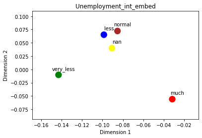

```python
np.set_printoptions(suppress=True) # stop using scientific notation

Unemployment = encoders["Unemployment"].classes_

# extract the x and y
x_list = Unemployment_weight[:,0]
y_list = Unemployment_weight[:,1]

index = 0

for x,y in zip(x_list, y_list):
    ar = Unemployment[index]
    plt.annotate(ar,# the label
                 xy=(x,y), # data
                 textcoords='offset points', # position of text
                 xytext=(10,10), # position offset of text
                ha='center')
    index += 1

c_value = ['blue','red','yellow','brown','green']
plt.scatter(x_list, y_list, s=150, c=c_value)
plt.xlabel('Dimension 1')
plt.ylabel('Dimension 2')
plt.title('Unemployment_int_embed')
plt.show()
```

```python
Transit_int_embed = []
Transit_weight = model.get_layer("Transit_int_embed").get_weights()[0]
Transit_weight.ndim
```

```
2
```

the dimension of the Trainst_weight is 2, so we dont need to use dimensionality reduction either.

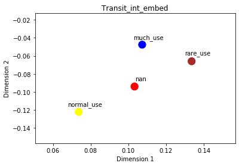

```python
np.set_printoptions(suppress=True)

Transit = encoders["Transit"].classes_

# extract the x and y
x_list = Transit_weight[:,0]
y_list = Transit_weight[:,1]

index = 0

for x,y in zip(x_list, y_list):
    ar = Transit[index]
    plt.annotate(ar,# the label
                 xy=(x,y), # data
                 textcoords='offset points', # position of text
                 xytext=(10,10), # position offset of text
                ha='center')
    index += 1
c_value = ['blue','red','yellow','brown']
plt.scatter(x_list, y_list, s=150, c=c_value)
plt.xlabel('Dimension 1')
plt.ylabel('Dimension 2')
plt.title('Transit_int_embed')
plt.show()
```

From the above plot, we could tell the result is not what we expected, because we acutually see "rare_use" and "much_use" being closed. However, the "normal_use" is farway from the other classes. The situation could be explained as maybe this two class of samples have some features which are simliar such as population, state, county..

```python
State_weight = model.get_layer("State_int_embed").get_weights()[0]
```

```python
State_weight.ndim
```

```
2
```

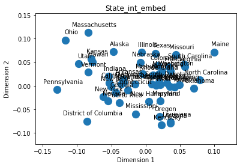

```python
State_int_embed = []
State_weight = model.get_layer("State_int_embed").get_weights()[0]

np.set_printoptions(suppress=True) # stop using scientific notation

State = encoders["State"].classes_

# extract the x and y
x_list = State_weight[:,0]
y_list = State_weight[:,1]

index = 0

for x,y in zip(x_list, y_list):
    ar = State[index]
    plt.annotate(ar,# the label
                 xy=(x,y), # data
                 textcoords='offset points', # position of text
                 xytext=(10,10), # position offset of text
                ha='center')
    index += 1
#c_value = ['blue','red','yellow','brown']
plt.scatter(x_list, y_list, s=150, )
plt.xlabel('Dimension 1')
plt.ylabel('Dimension 2')
plt.title('State_int_embed')
plt.show()
```